# Cyclistic Bike-Share - Case Study

#### 2. Daily Uses

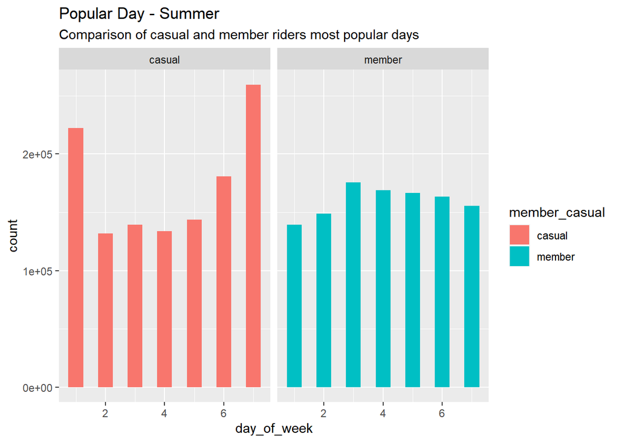

```r
ggplot(x2021_Summer, aes(x = day_of_week,fill=member_casual))+
  geom_histogram(binwidth = .5)+
  facet_wrap(~member_casual)+
  labs(title= "Popular Day - Summer", subtitle= "Comparison of casual and member riders most popular days")
```

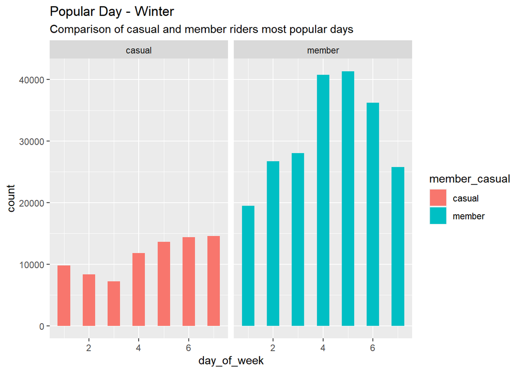

```r
ggplot(x2021_Winter, aes(x = day_of_week,fill=member_casual))+
  geom_histogram(binwidth = .5)+
  facet_wrap(~member_casual)+
  labs(title= "Popular Day - Winter", subtitle= "Comparison of casual and member riders most popular days")
```

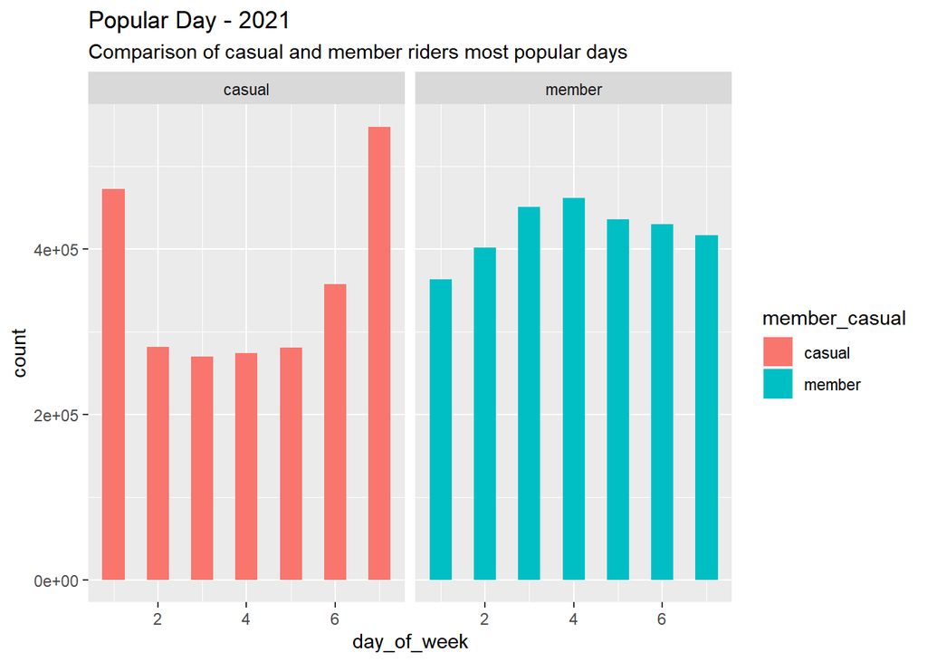

```r
ggplot(x2021_All, aes(x = day_of_week,fill=member_casual))+
  geom_histogram(binwidth = .5)+
  facet_wrap(~member_casual)+
  labs(title= "Popular Day - 2021", subtitle= "Comparison of casual and member riders most popular days")
```

#### 3. Ride Duration

- Member Riders again are consistent in their usage. *August’s drop in ride times seems against the trend. Further analysis may be required.
- Casual riders have longer rides in the summer months. *Longest ride time in August, with average ride times over 25 Minutes.* Regardless of month or season, casual riders get more time per ride than members.

```r
duration_avg<- read_csv("Duration_Avg - Sheet1.csv")
```

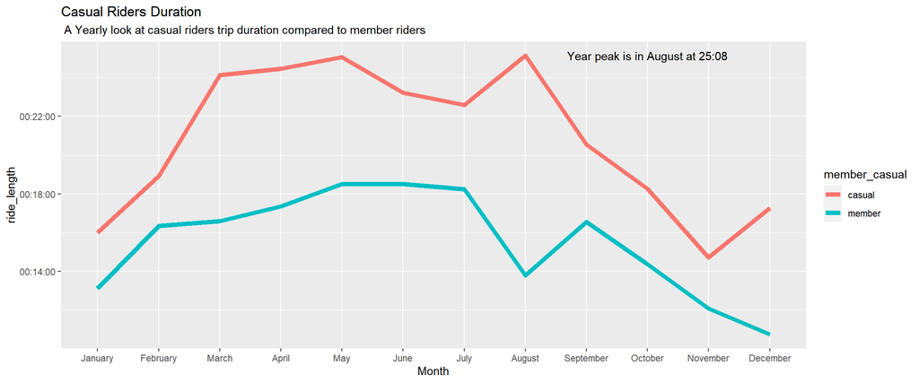

```r
ggplot(duration_avg, aes(x=Month, y = ride_length ,color=member_casual,group = member_casual))+
  geom_line(size =2)+
  scale_x_discrete(limits = c("January","February","March","April","May","June","July","August","September","October","November","December"))+
  labs(title = "Casual Riders Duration", subtitle = " A Yearly look at casual riders trip duration compared to member riders" )+
  annotate("text", x="October", y= 1508, label="Year peak is in August at 25:08")
```

#### 4. Starting Times

```r
X2021_All1 <- separate(x2021_All, started_at, into=c('date','time'), sep=" ")
x2021_All2 <- X2021_All1[order(X2021_All1$time),]

 x2021_All3 <- separate(x2021_All2, time, into=c('hour','minute'),sep = ":")
 x2021_All3$hour_of_day <- strtoi(x2021_All3$hour)
 x2021_All3 <- x2021_All3[order(x2021_All3$hour_of_day),]
```

- The shape of the graph for starting times is very similar between casual and member riders. The biggest difference is the 7am and 8 am peak you can see in member riders.
- The valley in the member graph, between 9am and 5 pm, again supports the idea member riders use the service mostly for commute.
- Casual riders continue into the later hours more than the members

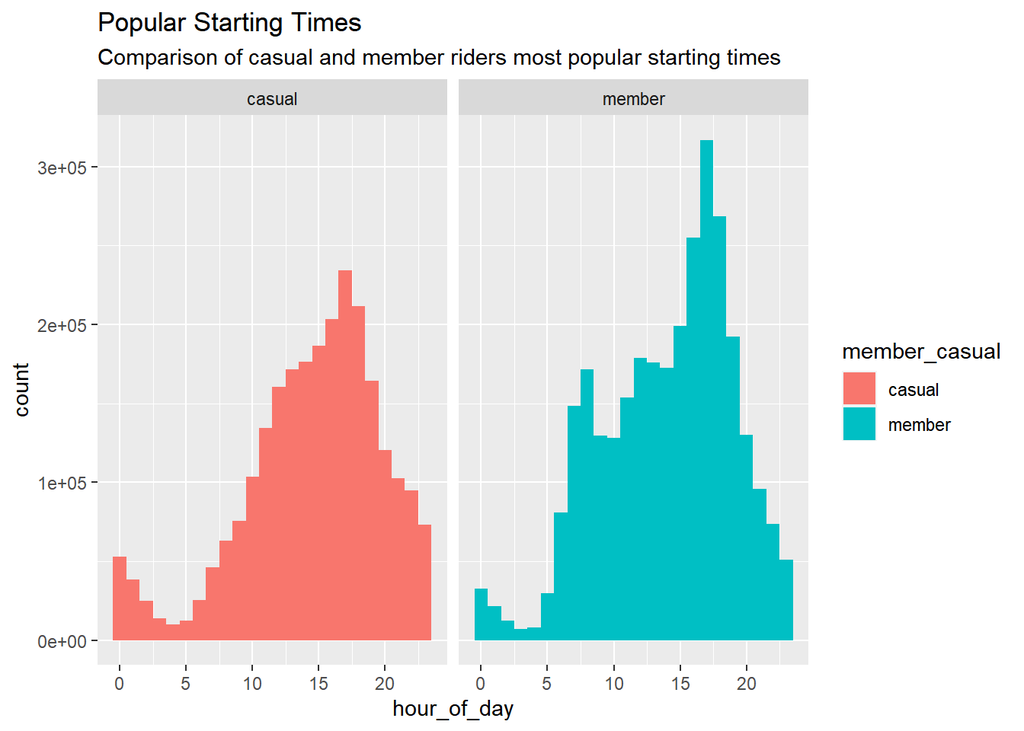

```r
ggplot(x2021_All3, aes(x = hour_of_day,fill=member_casual))+
    geom_histogram(binwidth = 1)+
    facet_wrap(~member_casual)+
    labs(title= "Popular Starting Times", subtitle= "Comparison of casual and member riders most popular starting times")
```

- The combined plot mirrors how simular the starting time activity is between the two groups

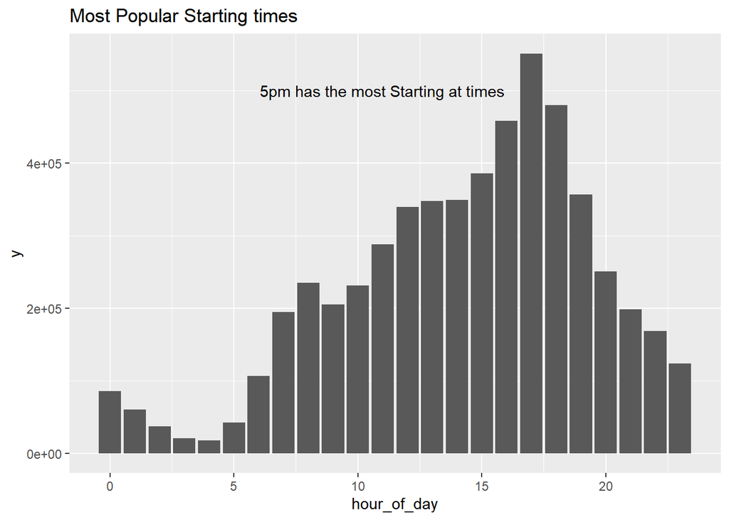

```r
ggplot(data=x2021_All3)+
  geom_bar(mapping=aes(hour_of_day))+
  labs(title = "Most Popular Starting times")+
  annotate("text", x = 11, y = 500000, label = "5pm has the most Starting at times")
```

#### 5. User errors

```r
overview <- read_csv("Cyclist Combo clean.csv")
```

```
## * `` -> ...22
## * `` -> ...23
## * `` -> ...24
## * `` -> ...25
## * `` -> ...26
## * ...
```

```r
error_table <- overview %>% select(c(Month,uncleaned_diff,casual_error,casual_error_per,casual_per))
View(error_table)
```

[output not shown]

### Share

#### How do casual riders use Cyclistic bikes differently than annual members?

- *Leisure vs Commute*
  - *Casual* riders use the service more for leisure: taking *longer* timed rides, *later* in the day, with a concentration of ride on the *weekend*.
  - *Member* riders are consistent users that use the service for commuting: Shorter rides, throughout the week, with usage spikes before 9am and after 5pm.
- *Learning Curve*
  - *Casual* riders have a higher percentage of rides over time limit and failed attempted rides, then the percentage of rides they have taken, compared to member riders. If a potential rider fails to use our service on their first ride, turning them into member riders will be impossible.

**The message for the digital marketing team, should be promoting multiple leisurely rides, all year long. Also the simple plan payment and usage plan that comes with being a member.**